# Lecture 1: Course introduction

SKOC42: Digital Marketing Communication 2026

nils.holmberg@iko.lu.se | ilkin.mehrabov@iko.lu.se

## Course design

- Theories and methods for digital marketing
- Design, report digital marketing campaign

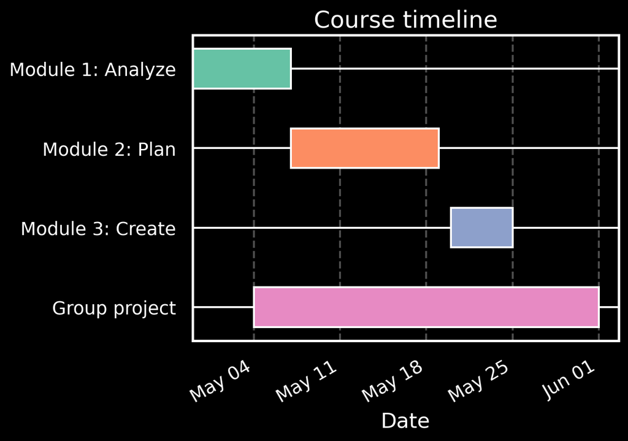

## Assignments and grading

| Assignment | Description | ECTS | Scale |
| --- | --- | --- | --- |
| Workshop 1 + 2 | Canvas handin | 1 + 1 | P/F |
| Group project | Report and presentation | 3 | A-F |
| Individual hall exam | Multiple choice questions | 2.5 | A-F |
| Course grade | Weighted average | 7.5 | A-F |

## Course literature

[figure not shown]

Chaffey and Chadwick (2022)

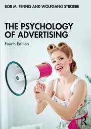

Fennis and Stroebe (2020)

[figure not shown]

Llamas and Belk (2013)

## Module 1: Analyze

- `Lecture 2: Digital marketing and advertising psychology`
- Readings:
  - Chaffey and Chadwick (2022), ch. 1
  - Fennis and Stroebe (2020), ch. 1 and 8
- Instructor: NH

|  | Mo | Tu | We | Th | Fr |
| --- | --- | --- | --- | --- | --- |
| Apr W18 |  | 28 | 29 | 30 | 01 |
| May W19 | 04 | 05 | 06 | 07 | 08 |
| May W20 | 11 | 12 | 13 | 14 | 15 |
| May W21 | 18 | 19 | 20 | 21 | 22 |
| May W22 | 25 | 26 | 27 | 28 | 29 |
| Jun W23 | 01 | 02 | 03 | 04 |  |

## Module 1: Analyze

- `Lecture 3: Situation analysis, personas, objectives`
- Readings:
  - Chaffey and Chadwick (2022), ch. 2, 4, 6
  - Fennis and Stroebe (2020), ch. 2, 3, 4
  - Llamas and Belk (2013), ch. 1, 3, 9
- Instructor: IM

|  | Mo | Tu | We | Th | Fr |
| --- | --- | --- | --- | --- | --- |
| Apr W18 |  | 28 | 29 | 30 | 01 |
| May W19 | 04 | 05 | 06 | 07 | 08 |
| May W20 | 11 | 12 | 13 | 14 | 15 |
| May W21 | 18 | 19 | 20 | 21 | 22 |
| May W22 | 25 | 26 | 27 | 28 | 29 |
| Jun W23 | 01 | 02 | 03 | 04 |  |

## Module 1: Analyze

- `Date: 2026-05-06`
- Event: Workshop 1
- Content: Consumer analysis (group 1 + 2)
- `Mandatory: 1.0 ECTS`
- Instructor: IM

|  | Mo | Tu | We | Th | Fr |
| --- | --- | --- | --- | --- | --- |
| Apr W18 |  | 28 | 29 | 30 | 01 |
| May W19 | 04 | 05 | 06 | 07 | 08 |
| May W20 | 11 | 12 | 13 | 14 | 15 |
| May W21 | 18 | 19 | 20 | 21 | 22 |
| May W22 | 25 | 26 | 27 | 28 | 29 |
| Jun W23 | 01 | 02 | 03 | 04 |  |

## Module 2: Plan

- `Lecture 4: Content marketing & social media`
- Readings:
  - Chaffey and Chadwick (2022), ch. 8, 9
  - Fennis and Stroebe (2020), ch. 6, 7, 8
  - Llamas and Belk (2013), ch. 5, 6, 24
- Instructor: IM

|  | Mo | Tu | We | Th | Fr |
| --- | --- | --- | --- | --- | --- |
| Apr W18 |  | 28 | 29 | 30 | 01 |
| May W19 | 04 | 05 | 06 | 07 | 08 |
| May W20 | 11 | 12 | 13 | 14 | 15 |
| May W21 | 18 | 19 | 20 | 21 | 22 |
| May W22 | 25 | 26 | 27 | 28 | 29 |
| Jun W23 | 01 | 02 | 03 | 04 |  |

## Module 2: Plan

|  | Mo | Tu | We | Th | Fr |
| --- | --- | --- | --- | --- | --- |
| Apr W18 |  | 28 | 29 | 30 | 01 |
| May W19 | 04 | 05 | 06 | 07 | 08 |
| May W20 | 11 | 12 | 13 | 14 | 15 |
| May W21 | 18 | 19 | 20 | 21 | 22 |
| May W22 | 25 | 26 | 27 | 28 | 29 |
| Jun W23 | 01 | 02 | 03 | 04 |  |

## Module 2: Plan

- `Date: 2026-05-13`
- Event: Workshop 2
- Content: Measuring digital marketing (group 1 + 2)
- `Mandatory: 1.0 ECTS`
- Instructor: NH

|  | Mo | Tu | We | Th | Fr |
| --- | --- | --- | --- | --- | --- |
| Apr W18 |  | 28 | 29 | 30 | 01 |
| May W19 | 04 | 05 | 06 | 07 | 08 |
| May W20 | 11 | 12 | 13 | 14 | 15 |
| May W21 | 18 | 19 | 20 | 21 | 22 |
| May W22 | 25 | 26 | 27 | 28 | 29 |
| Jun W23 | 01 | 02 | 03 | 04 |  |

## Team Project

- `Date: 2026-05-19`
- Event: Supervision 1
- Content: Project description review (group 1 + 2)
- Readings: -
- Instructor: IM

|  | Mo | Tu | We | Th | Fr |
| --- | --- | --- | --- | --- | --- |
| Apr W18 |  | 28 | 29 | 30 | 01 |
| May W19 | 04 | 05 | 06 | 07 | 08 |
| May W20 | 11 | 12 | 13 | 14 | 15 |
| May W21 | 18 | 19 | 20 | 21 | 22 |
| May W22 | 25 | 26 | 27 | 28 | 29 |
| Jun W23 | 01 | 02 | 03 | 04 |  |

## Module 3: Create

- `Lecture 6: Brand storytelling & Creative lab`
- Readings:
  - Chaffey and Chadwick (2022), ch. 8, 9
  - Fennis and Stroebe (2020), ch. 5, 7
  - Llamas and Belk (2013), ch. 7, 22, 25
- Instructor: IM

|  | Mo | Tu | We | Th | Fr |
| --- | --- | --- | --- | --- | --- |
| Apr W18 |  | 28 | 29 | 30 | 01 |
| May W19 | 04 | 05 | 06 | 07 | 08 |
| May W20 | 11 | 12 | 13 | 14 | 15 |
| May W21 | 18 | 19 | 20 | 21 | 22 |
| May W22 | 25 | 26 | 27 | 28 | 29 |
| Jun W23 | 01 | 02 | 03 | 04 |  |

## Module 3: Create

|  | Mo | Tu | We | Th | Fr |
| --- | --- | --- | --- | --- | --- |
| Apr W18 |  | 28 | 29 | 30 | 01 |
| May W19 | 04 | 05 | 06 | 07 | 08 |
| May W20 | 11 | 12 | 13 | 14 | 15 |
| May W21 | 18 | 19 | 20 | 21 | 22 |
| May W22 | 25 | 26 | 27 | 28 | 29 |
| Jun W23 | 01 | 02 | 03 | 04 |  |

## Team Project

- `Date: 2026-05-25`
- Event: Supervision 2
- Content: Campaign review (group 1 + 2)
- Readings: -
- Instructor: IM

|  | Mo | Tu | We | Th | Fr |
| --- | --- | --- | --- | --- | --- |
| Apr W18 |  | 28 | 29 | 30 | 01 |
| May W19 | 04 | 05 | 06 | 07 | 08 |
| May W20 | 11 | 12 | 13 | 14 | 15 |
| May W21 | 18 | 19 | 20 | 21 | 22 |
| May W22 | 25 | 26 | 27 | 28 | 29 |
| Jun W23 | 01 | 02 | 03 | 04 |  |

## Examination

- `Date: 2026-06-01`
- Event: Seminar
- Content: Team presentations (group 1 + 2)
- `Mandatory: 3.0 ECTS`
- Instructor: IM

|  | Mo | Tu | We | Th | Fr |
| --- | --- | --- | --- | --- | --- |
| Apr W18 |  | 28 | 29 | 30 | 01 |
| May W19 | 04 | 05 | 06 | 07 | 08 |
| May W20 | 11 | 12 | 13 | 14 | 15 |
| May W21 | 18 | 19 | 20 | 21 | 22 |
| May W22 | 25 | 26 | 27 | 28 | 29 |
| Jun W23 | 01 | 02 | 03 | 04 |  |

## Examination

- `Date: 2026-06-04`
- Event: Individual hall exam
- Content: Theories and methods in digital marketing
- `Mandatory: 2.5 ECTS`
- Instructor: NH

|  | Mo | Tu | We | Th | Fr |
| --- | --- | --- | --- | --- | --- |
| Apr W18 |  | 28 | 29 | 30 | 01 |
| May W19 | 04 | 05 | 06 | 07 | 08 |
| May W20 | 11 | 12 | 13 | 14 | 15 |
| May W21 | 18 | 19 | 20 | 21 | 22 |
| May W22 | 25 | 26 | 27 | 28 | 29 |
| Jun W23 | 01 | 02 | 03 | 04 |  |

## Marketing Campaign Cases

- Case 1: [Polestar](https://www.polestar.com)
- Case 2: [Ramlösa](https://ramlosa.se/produkter)
- Case 3: [The Royal Swedish Opera](https://www.operan.se/en/)
- Case 4: [Visit Malmö](https://www.visitmalmo.se/en/)
- Canvas [quiz link](https://canvas.education.lu.se/courses/37906/quizzes/97233)

[figure not shown]

## Next steps

**Lecture 2 (apr 29)**

- Lecture notes: https://cca-cce.github.io/osm-comm/web/edu/skoc42-lecture01.html

**References**

Chaffey, Dave, and Fiona Ellis Chadwick. 2022. *Digital Marketing. Hoboken*. NJ: Pearson.

Fennis, Bob M, and Wolfgang Stroebe. 2020. *The Psychology of Advertising*. Routledge.

Llamas, Rosa, and Russell Belk. 2013. *The Routledge Companion to Digital Consumption*. Routledge.